# Linear Regression

MDS. René Rosado González

## Introduction

We will work with a practical example of international relations. Octavio Amorim Neto(2012), a Brazilian political scientist, studied how Brazilian’s foreign policy has been strongly influenced by the United States. However, this weakened, and the influence was less evident now than during the Cold War. What was the reason for this trend?

## Libraries

Load, and install if necessary, the `tidyverse` and `tidymodels` libraries. You will need to have installed the `glmnet` and the `politicalds` package as well.

```r
# Install - load tidyverse
if(require(tidyverse) == FALSE){
  install.packages('tidyverse')
  library(tidyverse)
}else{
  library(tidyverse)
}
# Install - load tidymodels
if(require(tidymodels) == FALSE){
  install.packages('tidymodels')
  library(tidymodels)
}else{
  library(tidymodels)
}
# Install -glmnet
if(require(glmnet) == FALSE){
  install.packages('glmnet')
}
# Install - load patchwork
if(require(patchwork) == FALSE){
  install.packages('patchwork')
  library(patchwork)
}else{
  library(patchwork)
}
# Install - remotes
if(require(remotes) == FALSE){
  install.packages('remotes')
}
# Install politicalds
remotes::install_github('arcruz0/politicalds')
```

## Dataset

We will explore de `us_brazil` dataset from Urdinez and Cruz (2020).

```r
# Load the us_brazil dataset from the AER package
data('us_brazil', package = 'politicalds')
```

## Exploratory Data Analysis (EDA)

Perform an exploratory data analysis using the `glimpse` and `summary` functions.

```r
## Tidyway
glimpse(us_brazil)
```

```
## Rows: 62
## Columns: 3
## $ year          <dbl> 1946, 1947, 1948, 1949, 1950, 1951, 1952, 1953, 1954, 19…
## $ vote          <dbl> 0.8000000, 0.8648649, 0.8526316, 0.5434783, 0.9111111, 0…
## $ country_power <dbl> 0.0128, 0.0121, 0.0122, 0.0131, 0.0127, 0.0124, 0.0120, …
```

```r
# Summary
summary(us_brazil)
```

```
##       year           vote         country_power
##  Min.   :1946   Min.   :0.07955   Min.   :0.01080
##  1st Qu.:1961   1st Qu.:0.21792   1st Qu.:0.01475
##  Median :1976   Median :0.52174   Median :0.02170
##  Mean   :1976   Mean   :0.54335   Mean   :0.02007
##  3rd Qu.:1992   3rd Qu.:0.88337   3rd Qu.:0.02457
##  Max.   :2007   Max.   :1.00000   Max.   :0.02680
```

Create a `ggplot` of the time series of the [CINC Index](https://en.wikipedia.org/wiki/Composite_Index_of_National_Capability) in the `country_power` column and store it in an object called `left`.

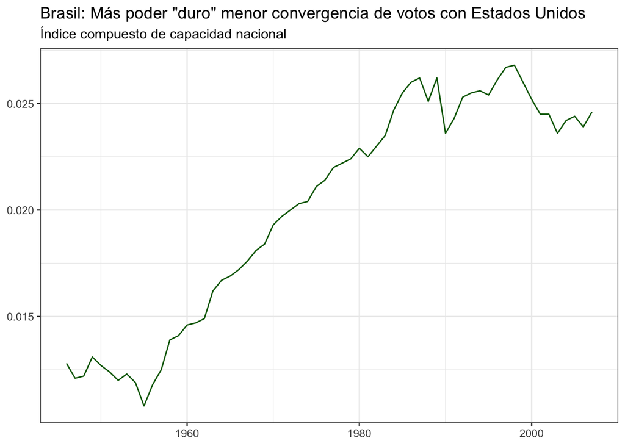

```r
# Serie de tiempo sobre ICN
left = us_brazil %>%
  # Set year to the x axis and country_power to the y axis
  ggplot(aes(x = year, y = country_power)) +
  # Set the linewidth to 0.5 and the color to  darkgreen
  geom_line(linewidth = 0.5, col = 'darkgreen') +
  # Select a custom theme
  theme_bw() +
  # Add proper labels
  labs(
    title = 'Brasil: Más poder "duro" menor convergencia de votos con Estados Unidos',
    # Use this subtitle as the y axis label
    subtitle = 'Índice compuesto de capacidad nacional'
    ) +
  theme(
    # Remove axist titles
    axis.title = element_blank()
  )

print(left)
```

Create a `ggplot` of the time series of the percentage of vote convergence with the US in the `vote` column and store it in an object called `right`.

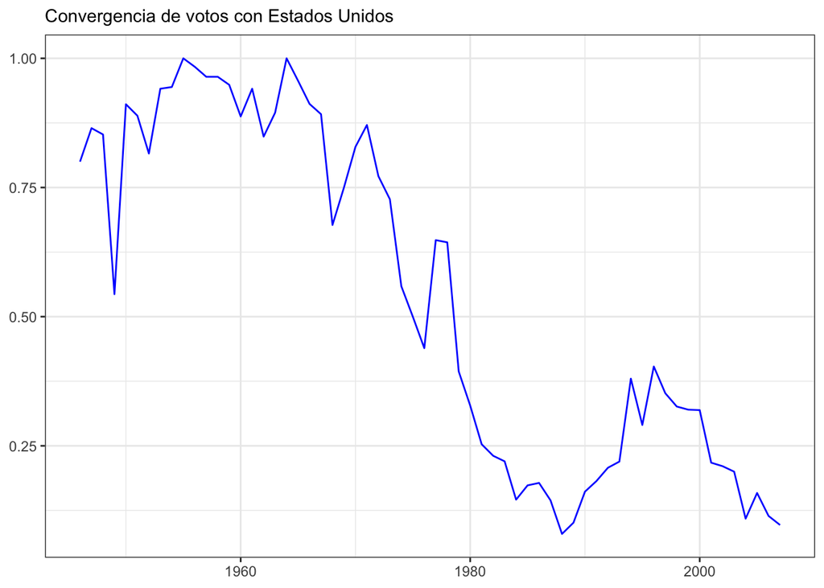

```r
# Serie de tiempo sobre Convergencia
right = us_brazil %>%
  # Set year to the x axis and vote to the y axis
  ggplot(aes(x = year, y = vote)) +
  # Set the linewidth to 0.5 and the color to blue
  geom_line(linewidth = 0.5, col = 'blue') +
  # Select a custom theme
  theme_bw() +
  # Add proper labels
  labs(
    # Use this subtitle as the y axis label
    subtitle = 'Convergencia de votos con Estados Unidos'
    ) +
  theme(
    # Remove axist titles
    axis.title = element_blank()
  )

print(right)
```

Create a two graph plot using patchwork grammar of graphics

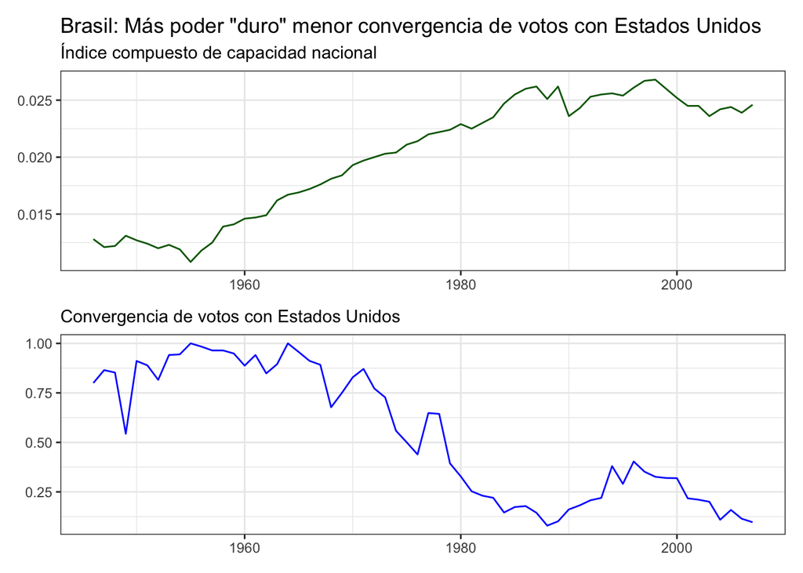

```r
left / right
```

We can plot the same relationship using a scatter plot

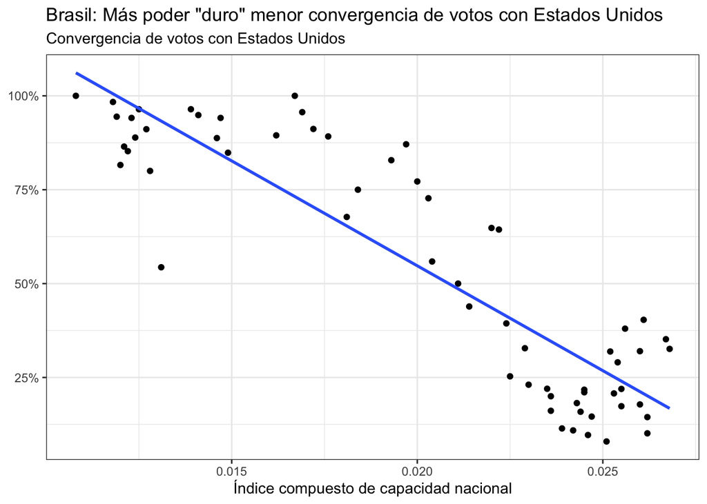

```r
us_brazil %>%
  # Set country_power to the x axis and vote to the y axis
  ggplot(aes(x = country_power, y = vote)) +
  # Add points
  geom_point() +
  # Add a linear regression line
  stat_smooth(method = 'lm', formula =  y ~ x, se = FALSE) +
  # Add proper labels
  labs(
    title = 'Brasil: Más poder "duro" menor convergencia de votos con Estados Unidos',
    # Use this subtitle as the y axis label
    subtitle = 'Convergencia de votos con Estados Unidos',
    x = 'Índice compuesto de capacidad nacional'
  ) +
  # Modify y scale labels
  scale_y_continuous(labels = scales::percent) +
  # Select a custom theme
  theme_bw() +
  theme(
    # Remove y axis title
    axis.title.y = element_blank()
  )
```

## Linear Regression

Create a model specification for the linear regression using the `tidymodels` framework.

```r
linear_model = linear_reg() %>%
  # Set the engine
  set_engine("glmnet") %>%
  # Set the mode
  set_mode('regression') %>%
  # Set hyperparameters to tune
  set_args(
    penalty = tune(),
    mixture = tune()
    )
```

```r
# Data splitting for samples
set.seed(123)
votes_split = initial_split(
  # Data to split
  data = us_brazil,
  # Proportions
  prop = 0.8,
  # Variable of interest
  strata = vote
)

# Get training and testing samples
votes_training = training(votes_split)
votes_testing = testing(votes_split)
```

```r
# Create cross-validation folds
set.seed(123)
votes_bootstrap = bootstraps(votes_training, times = 10, strata = vote)
```

```r
# Create a recipe
recipe = recipe(
  # Set a formula
  formula = vote ~ .,
  # Set input data
  data = votes_training
)
```

Make a workflow object with the recipe and model you just created.

```r
# Create a workflow
linear_workflow = workflow() %>%
  # Add your recipe
  add_recipe(recipe) %>%
  # Add your model
  add_model(linear_model)
```

Perform hyperparameter tuning on the workflow you just created using a `grid` of size 100.

```r
# Get parameters to tune
linear_parameters = linear_workflow %>%
  extract_parameter_set_dials()

# Create a tune grid
set.seed(123)
linear_tuning = tune_grid(
  object = linear_workflow,
  resamples = votes_bootstrap,
  param_info = linear_parameters,
  metrics = metric_set(yardstick::rmse),
  control = control_grid(verbose = TRUE),
  grid = 100
  )
```

Collect the tuning metrics and select the best model based on the `rmse` metric.

```r
# Collegt metrics
tuning_metrics = linear_tuning %>%
  collect_metrics() %>%
  # Arrange form higher mean to lower mean
  arrange(desc(mean))

# Select the best model
best_linear = linear_tuning %>%
  select_best('rmse')

# Print the best model
print(best_linear)
```

```
## # A tibble: 1 × 3
##   penalty mixture .config
##     <dbl>   <dbl> <chr>
## 1  0.0350   0.548 Preprocessor1_Model053
```

Finalize your workflow and make the last fit to collect the performance of the model with the testing sample.

```r
# Finalize the workflow with the best model
final_linear = linear_workflow %>%
  finalize_workflow(best_linear)

# Make the last fit
results_linear = final_linear %>%
  last_fit(
    split = votes_split,
    metrics = metric_set(yardstick::rmse)
    )

# Collect testing metrics
metrics_linear = results_linear %>%
  collect_metrics()

print(metrics_linear)
```

```
## # A tibble: 1 × 4
##   .metric .estimator .estimate .config
##   <chr>   <chr>          <dbl> <chr>
## 1 rmse    standard       0.140 Preprocessor1_Model1
```

Plot the regression plot of the model you just trained

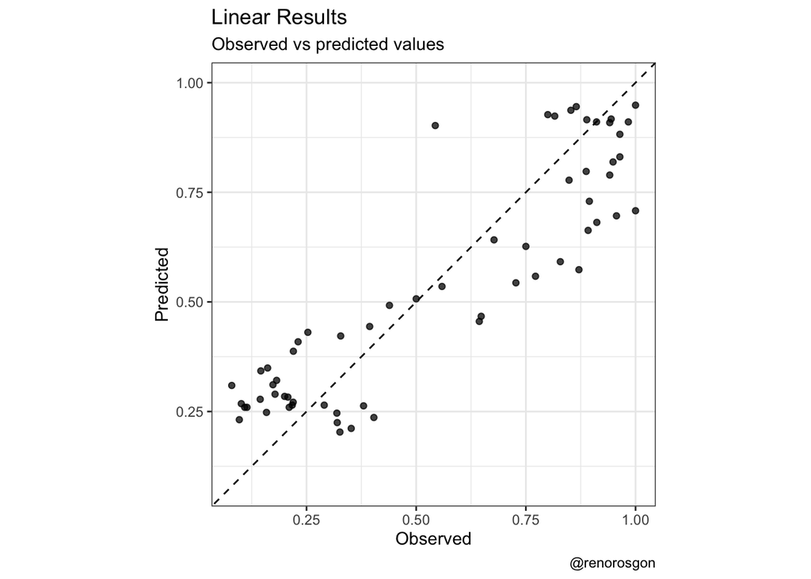

```r
# Extract the trained model
linear_trained = results_linear %>%
  extract_fit_parsnip()

# Add predictions
predictions_tb = augment(linear_trained, us_brazil)

# Regression plot (observed vs predicted)
ggplot(predictions_tb, aes(x = vote, y = .pred)) +
  # Create a scatter plot
  geom_point(alpha = 0.75) +
  # Add 45 degree, red, dashhed curve
  geom_abline(linetype = 'dashed') +
  # Make equal axis coordinates
  coord_obs_pred() +
  # Add proper labels
  labs(
    x = 'Observed',
    y = 'Predicted',
    title = 'Linear Results',
    subtitle = 'Observed vs predicted values',
    caption = '@renorosgon'
  ) +
  # Use a default theme
  theme_bw() +
  # Modify legend attributes using legend.attribute
  theme(
     # Delete legend title
    legend.title = element_blank(),
    # Delete legend background
    legend.background = element_blank(),
    # Delete legend box background
    legend.box.background = element_blank(),
    # Make legend key fill transparent
    legend.key = element_rect(fill = "transparent"),
    # Modify the legend position to de coordinates c(0.1, 0.95)
    legend.position = c(0.1, 0.95),
    # Modify the height of the legend key to 0.5 cm
    legend.key.height = unit(0.5,'cm')
  )
```

As you can see, there are some observations with a better fit (a lower prediction error). Let see if we can understand why it is so. Create the following plots and compare them to see what’s happening.

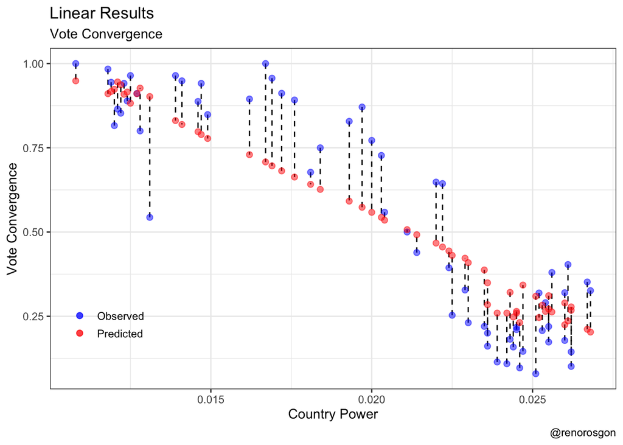

```r
# Create a ggplot with the prediction_tb. Use the income variable in the x axis
ggplot(predictions_tb, aes(x = country_power)) +
  # Add a segment line
  geom_segment(
    aes(
      # Set the income variable in the x axis
      x = country_power, xend = country_power,
      # Set pack as y and .pred as yend
      y = vote, yend = .pred
      ),
    # Set the linetype to dashed
    linetype = 'dashed'
    ) +
  # Add a scatter plot with the packs variable. Color the dots as 'Observed'
  geom_point(
    aes(y = vote, col = 'Observed'),
    alpha = 0.5, size = 2
    ) +
  # Add a scatter plot with the .pred variable. Color the dots as 'Predicted'
  geom_point(
    aes(y = .pred, col = 'Predicted'),
    alpha = 0.5 , size = 2
    ) +
  # Set color to blue and red
  scale_color_manual(values = c('blue','red')) +
  # Add proper labels
  labs(
    x = 'Country Power',
    y = 'Vote Convergence',
    title = 'Linear Results',
    subtitle = 'Vote Convergence',
    caption = '@renorosgon'
  ) +
  # Use a default theme
  theme_bw() +
  # Modify legend attributes using legend.attribute
  theme(
     # Delete legend title
    legend.title = element_blank(),
    # Delete legend background
    legend.background = element_blank(),
    # Delete legend box background
    legend.box.background = element_blank(),
    # Make legend key fill transparent
    legend.key = element_rect(fill = "transparent"),
    # Modify the legend position to de coordinates c(0.1, 0.95)
    legend.position = c(0.1, 0.2),
    # Modify the height of the legend key to 0.5 cm
    legend.key.height = unit(0.5,'cm')
  )
```

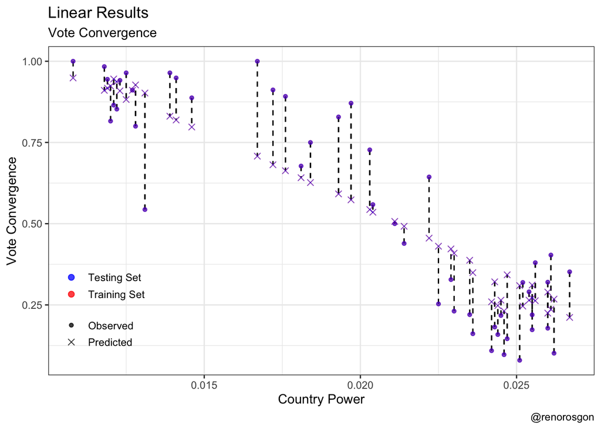

```r
# Plot decision boundatires
training = recipe %>%
  prep() %>%
  juice() %>%
  augment(x = linear_trained) %>%
  mutate(set = 'Training Set')

testing = recipe %>%
  prep() %>%
  bake(new_data = votes_training) %>%
  augment(x = linear_trained) %>%
  mutate(set = 'Testing Set')

predictions_tb = bind_rows(training, testing)

ggplot(predictions_tb, aes(x = country_power)) +
  # Add a segment line
  geom_segment(
    aes(
      # Set the income variable in the x axis
      x = country_power, xend = country_power,
      # Set pack as y and .pred as yend
      y = vote, yend = .pred
      ),
    # Set the linetype to dashed
    linetype = 'dashed'
    )  +
  # Add a scatter plot with the packs variable. Color the dots as 'Observed'
  geom_point(
    aes(y = vote, shape = 'Observed', col = set),
    alpha = 0.5, size = 2
    ) +
  # Add a scatter plot with the .pred variable. Color the dots as 'Predicted'
  geom_point(
    aes(y = .pred, shape = 'Predicted', col = set),
    alpha = 0.5 , size = 2
    ) +
  # Set color to blue and red
  scale_color_manual(values = c('blue','red')) +
  # Modify shape
  scale_shape_manual(values = c(20,4)) +
  # Add proper labels
  labs(
    x = 'Country Power',
    y = 'Vote Convergence',
    title = 'Linear Results',
    subtitle = 'Vote Convergence',
    caption = '@renorosgon'
  )+
  # Use a default theme
  theme_bw() +
  # Modify legend attributes using legend.attribute
  theme(
     # Delete legend title
    legend.title = element_blank(),
    # Delete legend background
    legend.background = element_blank(),
    # Delete legend box background
    legend.box.background = element_blank(),
    # Make legend key fill transparent
    legend.key = element_rect(fill = "transparent"),
    # Modify the legend position to de coordinates c(0.1, 0.95)
    legend.position = c(0.1, 0.2),
    # Modify the height of the legend key to 0.5 cm
    legend.key.height = unit(0.5,'cm'),
    # Modify the height of the legend key to 0.5 cm
    legend.spacing.y = unit(0.015,'cm')
  )
```